# P2_Entrega_final

GRUPO-07

2022-06-22

## **Profesor:**

Dante Randall Gallo Torres

## **Integrantes:**

Estudiantes

Carrera

Porcentaje de participación

Mejia Caicedo, Sonia Reymi(L)

Ingeniería Industrial

```
      100%
```

Ccorisoncco Merino, Esmeralda

Ingeniería Industrial

```
      100%
```

Tomanguilla Ramirez,Maykol Jhunior

Ingeniería Industrial

```
      100%
```

Malqui Vicuña, Greysi Nataly

Ingeniería Industrial

```
      100%
```

Figueroa Galvez, Chealsie Jaxira

Ingeniería Industrial

```
      100%
```

[figure not shown]

# **“EL USO DE REDES SOCIALES EN LOS ESTUDIANTES DE UTEC”**

## **Introducción**

### Relevancia:

Las redes sociales son un medio de interacción muy común entre jóvenes, más aún entre universitarios que lo destinan con diversos usos, por esta razón nos llamó la atención investigar acerca de ello. Nuestro proyecto de investigación se basa en el uso de redes sociales en estudiantes de la universidad de ingeniería y tecnología (UTEC) para conocer el tiempo empleado, la finalidad, ventajas y consecuencias que conlleva su uso.

**Objetivo principal:** Investigar el uso de redes sociales entre los estudiante de UTEC, con el fin de analizar la relación que existe entre las variables propuestas por nuestro proyecto.

**Objetivos secundarios:** 1. Determinar la finalidad de uso de Redes sociales que los estudiantes de UTEC poseen. 2. Conocer la red social más frecuente entre los estudiantes y el tiempo empleado. 3. Utilizar descriptores estadísticos para la relación entre variables.

### Planificación:

Realizamos un diagrama de Gantt con las actividades para la elaboracion de nuestro proyecto, respetando las fechas de entrega durante el ciclo para lograr un trabajo ordenado y eficaz.

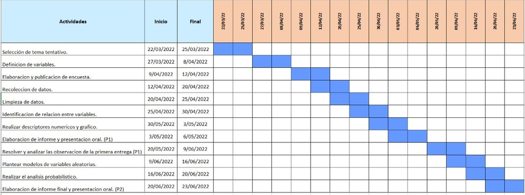

Diagrama de Gantt

## **Datos**

### Proceso de recolección de datos:

Para realizar la recolección de datos, creamos una encuesta que cuenta con 13 variables y está dirigida a todos los estudiantes de UTEC. Optamos por realizar nuestra propia encuesta, debido a que estamos buscando una base de datos que se adecue de manera muy específica al propósito de nuestra investigación. Las condiciones en que realizamos esta encuesta fue de manera virtual de una forma rápida y sencilla para los estudiantes, pues la mayoría cuenta con un dispositivo tecnológico para poder realizarla. La difusión de esta encuesta fue a través de redes sociales, para ser específicos, WhatsApp y Telegram, haciendo uso de los grupos de estudios de la universidad, siempre tomando en cuenta el no generar spam. Y como estrategia para motivar a los estudiantes a realizar nuestra encuesta, realizaremos un sorteo.

### Población, muestra y muestreo:

- Población: Estudiantes de UTEC que están cursando el semestre 2022-1.
- Muestra: Todos los estudiantes de la universidad que tengan entre 15 y 30 años,nuestro tamaño de muestra es de 203 y tiene una representatividad adecuada, a partir de ello trabajamos a través de la recolección de datos para obtener nuestra muestra.
- Muestreo: Es un muestreo por conveniencia

### Variables:

[output not shown]

# **Limpieza de datos**

Antes de dar inicio a nuestra limpieza de datos, realizaremos la lectura de nuestra base de datos para ejecutar todo el trabajo.

Luego de ello, observamos que en nuestra base de datos encontramos dos columnas que no necesitaremos para nuestro estudio, las cuales son la marca temporal y la dirección de correo electrónico. Por ello eliminaremos estas dos columnas de la siguiente formas:

```r
DBT <- DBT[,c(3:15)]#En esta linea de código se están eliminando "Marca temporal" y "Dirección de correo electrónico"
DBT <- DBT[complete.cases(DBT),]
```

Con la función names, podemos conocer el nombre de todas nuestras variables.

```r
names(DBT)
```

```
##  [1] "Edad"
##  [2] "Género"
##  [3] "Carrera"
##  [4] "Ciclo"
##  [5] "¿Cuántos dispositivos tecnológicos tienes para navegar en redes sociales?"
##  [6] "¿Qué dispositivo usas con mayor frecuencia  para navegar en las redes sociales?"
##  [7] "¿Cuántas aplicaciones de redes sociales tienes instaladas?"
##  [8] "¿Cuál es la red social que usas con más frecuencia?"
##  [9] "¿Cuántas horas estudias al día?, fuera de clases"
## [10] "¿Revisas las redes sociales antes de dormir?"
## [11] "Aproximadamente, ¿cuántas horas al día dedicas a las redes sociales?"
## [12] "¿Te distraes en clase usando alguna red social?"
## [13] "¿Con qué fin usas las redes?"
```

Ahora generada la base de datos de “DatosR” a “DBT” procederemos a la modificación de las variables para poder manejar con mayor facilidad.

```r
rename (DBT,
        Edad = "Edad",
        Genero = "Género",
        Carrera = "Carrera",
        Ciclo = "Ciclo",
        CantiDIS = "¿Cuántos dispositivos tecnológicos tienes para navegar en redes sociales?",
        DispoRs = "¿Qué dispositivo usas con mayor frecuencia  para navegar en las redes sociales?",
        CantiAPP= "¿Cuántas aplicaciones de redes sociales tienes instaladas?",
        Rsfav = "¿Cuál es la red social que usas con más frecuencia?",
        HsFC = "¿Cuántas horas estudias al día?, fuera de clases",
        RevRs = "¿Revisas las redes sociales antes de dormir?",
        HorRs = "Aproximadamente, ¿cuántas horas al día dedicas a las redes sociales?",DisCLAS = "¿Te distraes en clase usando alguna red social?",
        FinRs = "¿Con qué fin usas las redes?"
) -> DBT
```

Ahora, realizaremos la verificación de datos y el numero de casos completos e incompletos.

```r
sum(is.na(DBT)) #cantidad de datos incompletos de DBT
```

```
## [1] 0
```

```r
sum(!is.na(DBT)) # Los datos completos.
```

```
## [1] 2639
```

```r
sum(complete.cases(DBT[,1:13])) # Los casos completos de la base de datos.
```

```
## [1] 203
```

```r
sum(!complete.cases(DBT[,1:13])) # La cantidad de casos incompletos.
```

```
## [1] 0
```

Limpiamos las variables Carrera y Finalidad de uso (FinRs), mediante su verificación ya que estas cuentan con caracteres no permitidos.

-> Carrera

```r
DBT$Carrera[DBT$Carrera == "Administración y Negocios digitales"] <- "Administracion y Negocios digitales"
DBT$Carrera[DBT$Carrera == "Bioingeniería"] <- "Bioingenieria"
DBT$Carrera[DBT$Carrera == "Ciencia de la Computación"] <- "Ciencia de la Computacion"
DBT$Carrera[DBT$Carrera == "Ingeniería de la Energía"] <- "Ingenieria de la Energia"
DBT$Carrera[DBT$Carrera == "Ingeniería Industrial"] <- "Ingenieria Industrial"
DBT$Carrera[DBT$Carrera == "Ingeniería Química"] <- "Ingenieria Quimica"
DBT$Carrera[DBT$Carrera == "Ingeniería Mecánica"] <- "Ingenieria Mecanica"
DBT$Carrera[DBT$Carrera == "Ingeniería Mecatrónica"] <- "Ingenieria Mecatronica"
DBT$Carrera[DBT$Carrera == "Ingeniería Civil"] <- "Ingenieria Civil"
DBT$Carrera[DBT$Carrera == "Ingeniería Electrónica"] <- "Ingenieria Electronica"
DBT$Carrera[DBT$Carrera == "Ingeniería Ambiental"] <- "Ingenieria Ambiental"
```

-> FinRS

```r
DBT$FinRs[DBT$FinRs == "Académico"] <- "Academico"
DBT$FinRs[DBT$FinRs == "Académico, Económico"] <- "Academico, Economico"
DBT$FinRs[DBT$FinRs == "Académico, Económico, Entretenimiento"] <- "Academico, Economico, Entretenimiento"
DBT$FinRs[DBT$FinRs == "Académico, Entretenimiento"] <- "Academico, Entretenimiento"
DBT$FinRs[DBT$FinRs == "Académico, Laboral, Económico"] <- "Academico, Laboral, Economico"
DBT$FinRs[DBT$FinRs == "Académico, Laboral, Entretenimiento"] <- "Academico, Laboral, Entretenimiento"
DBT$FinRs[DBT$FinRs == "Académico, Social"] <- "Academico, Social"
DBT$FinRs[DBT$FinRs == "Académico, Social, Entretenimiento"] <- "Academico, Social, Entretenimiento"
DBT$FinRs[DBT$FinRs == "Académico, Social, Económico"] <- "Academico, Social, Economico"
DBT$FinRs[DBT$FinRs == "Académico, Social, Económico, Entretenimiento"] <- "Academico, Social, Economico, Entretenimiento"
DBT$FinRs[DBT$FinRs == "Académico, Social,  Entretenimiento"] <- "Academico, Social,  Entretenimiento"
DBT$FinRs[DBT$FinRs == "Académico, Social, Laboral"] <- "Academico, Social, Laboral"
DBT$FinRs[DBT$FinRs == "Académico, Social, Laboral, Económico, Entretenimiento"] <- "Academico, Social, Laboral, Economico, Entretenimiento"
DBT$FinRs[DBT$FinRs == "Académico, Social, Laboral, Entretenimiento"] <- "Academico, Social, Laboral, Entretenimiento"
```

–> RevRs

```r
table(DBT$RevRs)#Observamos que la variable cuenta con un error en uno de sus caracteres
```

```
##
##  NO  SI  Sí
##  29 173   1
```

```r
DBT$RevRs[DBT$RevRs == "Sí"] <- "SI"
```

Como tenemos dos variables con respuesta de opción multiple, usaremos el comando grep para poder separar las respuestas. –>Rsfav

```r
DBT$WhatsApp <- NA
DBT$Instagram <- NA
DBT$Telegram <- NA
DBT$Tiktok <- NA
DBT$Facebook<- NA
DBT$Twitter <- NA
DBT$Youtube <- NA
DBT$Kwai <- NA
DBT$Discord <- NA

DBT$WhatsApp[grep("WhatsApp", DBT$Rsfav)] <- "Sí"
DBT$Instagram[grep("Instagram", DBT$Rsfav)] <- "Sí"
DBT$Telegram[grep("Telegram", DBT$Rsfav)] <- "Sí"
DBT$Tiktok[grep("Tik tok", DBT$Rsfav )] <- "Sí"
DBT$Facebook[grep("Facebook",DBT$Rsfav)] <- "Sí"
DBT$Twitter[grep("Twitter", DBT$Rsfav)] <- "Sí"
DBT$Youtube[grep("Youtube", DBT$Rsfav)] <- "Sí"
DBT$Kwai[grep("Kwai", DBT$Rsfav)] <- "Sí"
DBT$Discord[grep("Discord",DBT$Rsfav)] <- "Sí"

DBT$WhatsApp[is.na(DBT$WhatsApp)] <- "No"
DBT$Instagram[is.na(DBT$Instagram)] <- "No"
DBT$Telegram[is.na(DBT$Telegram)] <- "No"
DBT$Tiktok[is.na(DBT$Tiktok )] <- "No"
DBT$Facebook[is.na(DBT$Facebook)] <- "No"
DBT$Twitter[is.na(DBT$Twitter)] <- "No"
DBT$Youtube[is.na(DBT$Youtube)] <- "No"
DBT$Kwai[is.na(DBT$Kwai)] <- "No"
DBT$Discord[is.na(DBT$Discord)] <- "No"
```

–> FinRs

```r
DBT$Academico <- NA
DBT$Entretenimiento <- NA
DBT$Laboral <- NA
DBT$Social <- NA
DBT$Economico <- NA

DBT$Academico[grep("Academico", DBT$FinRs)] <- "Sí"
DBT$Entretenimiento[grep("Entretenimiento", DBT$FinRs)] <- "Sí"
DBT$Laboral[grep("Laboral", DBT$FinRs)] <- "Sí"
DBT$Social[grep("Social", DBT$FinRs)] <- "Sí"
DBT$Economico[grep("Economico",DBT$FinRs)] <- "Sí"

DBT$Academico[is.na(DBT$Academico)] <- "No"
DBT$Entretenimiento[is.na(DBT$Entretenimiento)] <- "No"
DBT$Laboral[is.na(DBT$Laboral)] <- "No"
DBT$Social[is.na(DBT$Social)] <- "No"
DBT$Economico[is.na(DBT$Economico)] <- "No"
```

# **Análisis descriptivo**

## Descriptores numéricos y gráficos:

### **Edad**

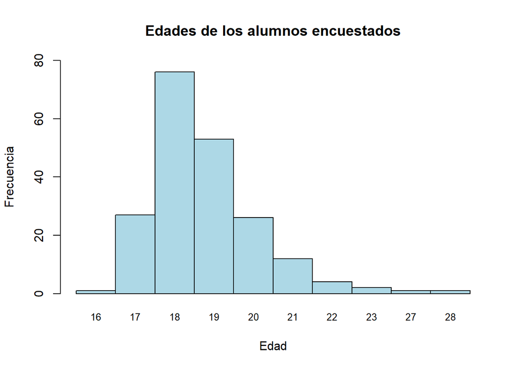

```r
barplot(table(DBT$Edad), main = "Edades de los alumnos encuestados", ylab = "Frecuencia", xlab = "Edad", col="lightblue",ylim = c(0,80),space = 0,cex.names = 0.8)
```

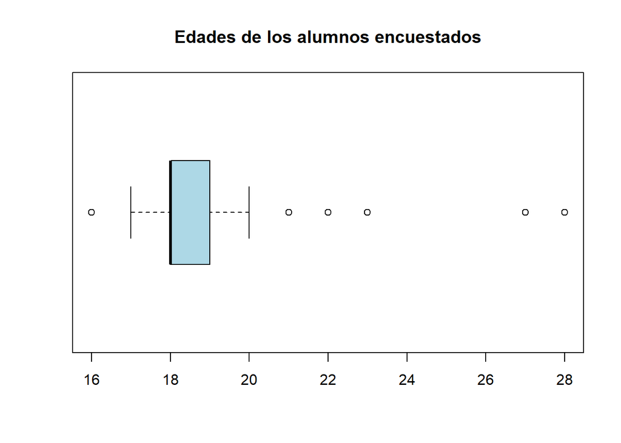

```r
boxplot(DBT$Edad,main="Edades de los alumnos encuestados",col="lightblue",horizontal = T)
```

```r
summary(DBT$Edad)
```

```
##    Min. 1st Qu.  Median    Mean 3rd Qu.    Max.
##   16.00   18.00   18.00   18.77   19.00   28.00
```

### **Genero**

- Variable categórica nominal
- La mayoria de encuestados son del género masculino, con 106 estudiantes.
- La minoria son del género prefiero no decirlo, con 2 estudiantes.
- Con esta variable podemos definir la representatividad de nuestra muestra.

```r
table(DBT$Genero)
```

```
##
##            Femenino           Masculino Prefiero no decirlo
##                  95                 106                   2
```

### **Carrera**

- Variable categórica nominal
- Al aplicar la funcion table, podemos determinar que la mayoria de estudiantes son de la carrera de Ingeniería Industrial y la minoria de la carrera Ciencia de datos.

```r
table(DBT$Carrera)
```

```
##
##             Bioingenieria          Ciencia de datos Ciencia de la computación
##                        19                         4                         8
##      Ingenieria Ambiental          Ingenieria Civil    Ingenieria Electronica
##                        10                        42                         9
##     Ingenieria Industrial       Ingenieria Mecanica    Ingenieria Mecatronica
##                        80                         8                        17
##        Ingenieria Quimica
##                         6
```

### **Ciclo**

- Variable categórica ordinal
- Al aplicar la funcion table, podemos determinar que la mayoria de estudiantes son del segundo ciclo.
- Solo tenemos un estudiante del octavo ciclo.

```r
table(DBT$Ciclo)
```

```
##
##   1   2   3   4   5   6   7   8
##  17 133  27   6   9   5   5   1
```

### **¿Cuántos dispositivos tecnológicos tienes para navegar en redes sociales? - CantiDIS**

- Variable numérica discreta
- Con la funcion moda, determinamos cual es el numero de dispositivos mas comunes entre los estudiantes para navegar en las redes sociales, el cual es 2.

```r
mfv(DBT$CantiDIS)
```

```
## [1] 2
```

### **¿Qué dispositivo usas con mayor frecuencia para navegar en las redes sociales? - DispoRs**

- Variable categórica nominal
- Al emplear la funcion table, podemos definir que mas de la mitad de los estudiantes usan el celular como dipositivo para navegar en redes sociales y esto podemos comprobarlo con la grafica que empleamos.

```r
table(DBT$DispoRs)
```

```
##
##       Celular        Laptop Tablet o IPad
##           170            32             1
```

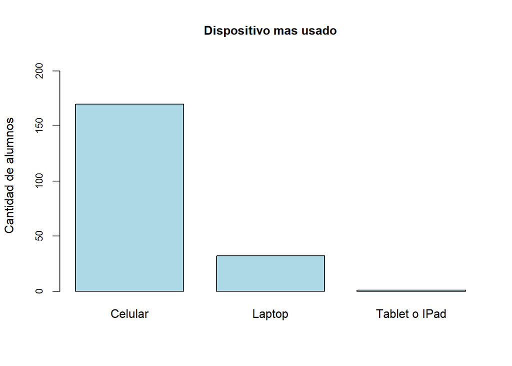

```r
barplot(table(DBT$DispoRs), col = "lightblue", main = "Dispositivo mas usado",cex.main = 1 ,space = 0.3, ylim = c(0,210),cex.names = 1, cex.axis = 0.8,ylab = "Cantidad de alumnos")
```

### **¿Cuántas aplicaciones de redes sociales tienes instaladas? - CantiAPP**

- Variable numérica discreta
- Gracias a la funcion moda, determinamos que la mayoria de estudiantes tiene 3 aplicaciones instaladas para usar las redes sociales.
- El mínimo de aplicaciones en redes sociales instaladas es 1 y el máximo es 20.

```r
mfv(DBT$CantiAPP)
```

```
## [1] 3
```

```r
table(DBT$CantiAPP)
```

```
##
##  1  2  3  4  5  6  7  8  9 10 12 13 14 15 17 20
##  6 14 41 35 33 23 18 19  2  3  2  2  1  2  1  1
```

### **¿Cuál es la red social que usas con más frecuencia? - Rsfav**

- Variable categórica nominal
- Luego de haber usado el comando greep para la separación de datos de nuestra variable (Rsfav), realizamos el siguiente código para poder representar nuestra grafica de frecuencia.
- Al analizar la gráfica, se observa que la red social WhatsApp predomina ante las otras redes que se encuentraban en las respuestas, siendo más de la mitad del total de datos, el cual obtuvimos con la función table.

```r
table(Redeslevels)
```

```
## Redeslevels
##  WhastApp Instagram  Telegram    Tiktok  Facebook   Twitter   Youtube      Kwai
##       176        86        43        54        80        14        73         3
##   Discord
##        27
```

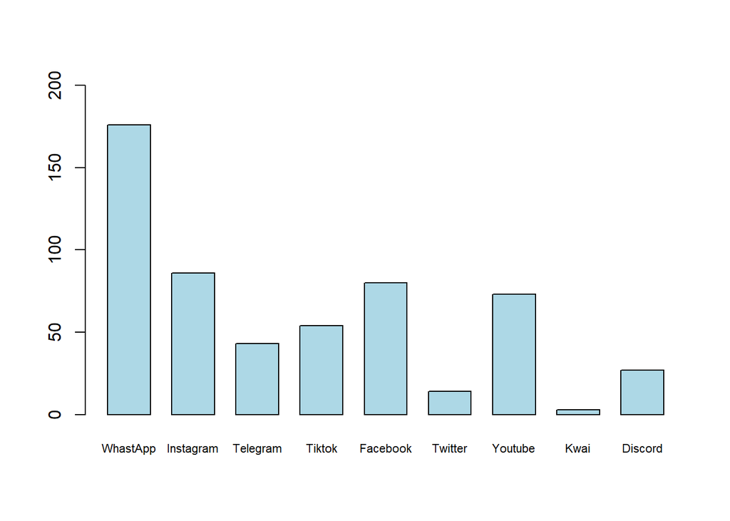

```r
barplot(table(Redeslevels), space = 0.5,cex.names = 0.7, ylim = c(0,200), col = 'lightblue')
```

### **¿Cuántas horas estudias al día?, fuera de clases - HsFC**

- Variable numerica discreta
- Al emplear la función moda, nos resulta que las horas de estudio más comunes entre los estudiantes es de 4 horas, pero al hacer una grafico de barras podemos notar que no es mucha la diferencia entre 4 horas y 5 horas.

```r
mfv(DBT$HsFC)
```

```
## [1] 4
```

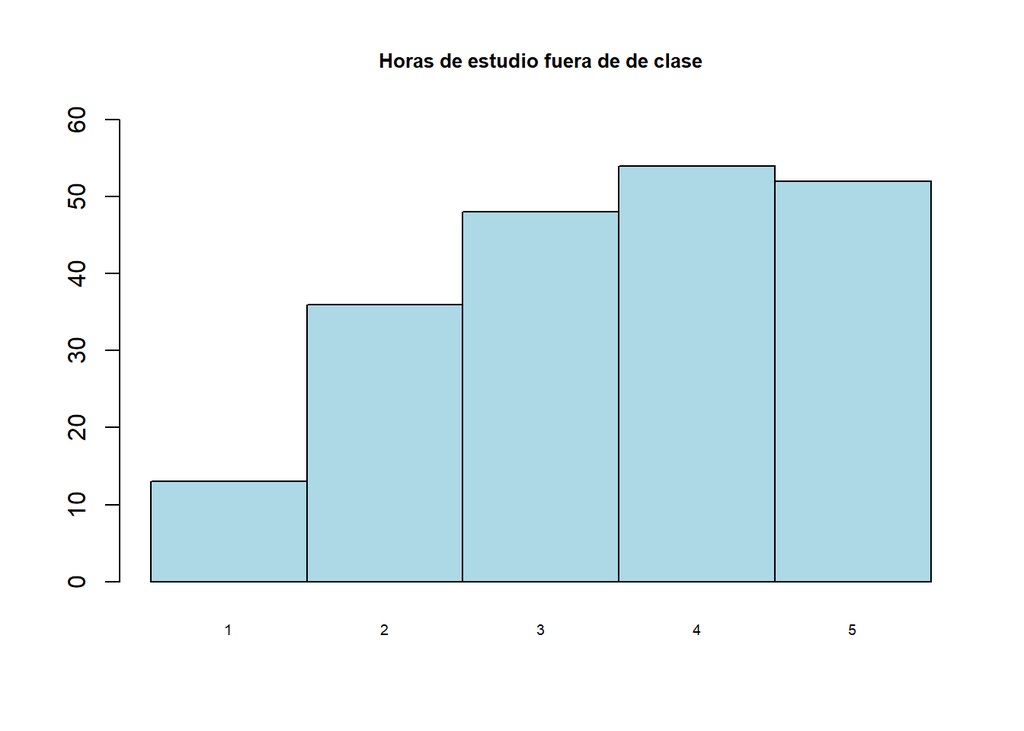

```r
data_HsFC<-factor(DBT$HsFC , levels = c("1","2","3", "4", "5"),ordered = T)
barplot(table(data_HsFC),col = "lightblue", main = "Horas de estudio fuera de de clase",cex.names = 0.6,space= 0,ylim = c(0,60),cex.main = 0.8)
```

### **Aproximadamente, ¿cuántas horas al día dedicas a las redes sociales? - HorRs**

- Variable numérica discreta
- Con la funcion table, obtenemos la cantidad de horas dedicadas a las redes sociales con más frecuencia entre los estudiantes.

```r
table(DBT$HorRs)
```

```
##
##  1  2  3  4  5  6  7  8
## 37 75 50 24  7  4  1  5
```

### **¿Te distraes en clase usando alguna red social? - DisCLAS**

- Variable categorica nominal
- La mayoria de estudiante respondieron “a veces” con respecto a la distraccion en clase con las redes sociales.

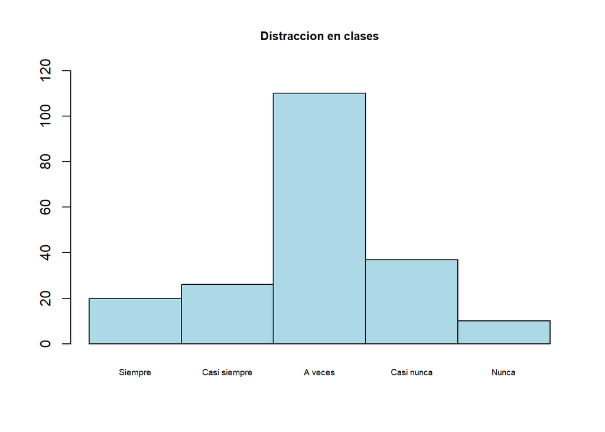

```r
data_DisCLAS<-factor(DBT$DisCLAS , levels = c("Siempre","Casi siempre","A veces", "Casi nunca", "Nunca"),ordered = T)
barplot(table(data_DisCLAS),col = "lightblue", main = "Distraccion en clases",cex.names = 0.6,space= 0,ylim = c(0,120),cex.main = 0.8)
```

### **¿Con qué fin usas las redes? - FinRs**

- Variable categorica nominal
- La mayoría de estudiante usan las redes sociales con la finalidad de entretenerse.

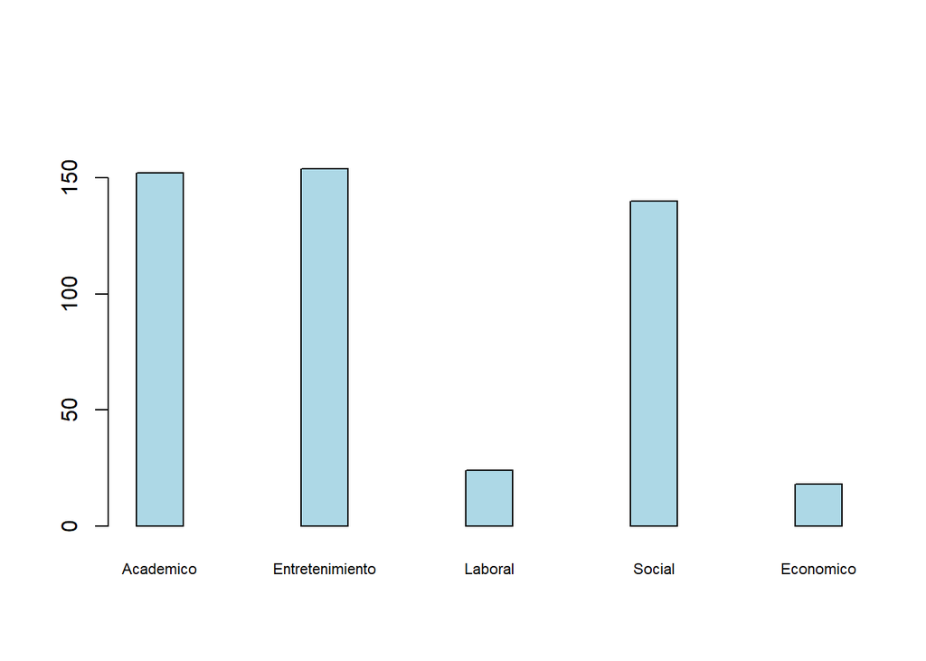

```r
tablafin <- table(Finlevels)
barplot(tablafin, space = 2.5,cex.names = 0.7, ylim = c(0,180), col="lightblue")
```

```r
table(Finlevels)
```

```
## Finlevels
##       Academico Entretenimiento         Laboral          Social       Economico
##             152             154              24             140              18
```

# **Gráficos de interacción entre dos variables:**

## Cantidad de dispositivos - Horas de uso de redes sociales

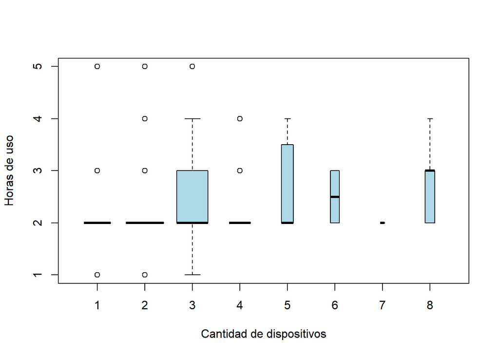

```r
boxplot(DBT$CantiDIS ~ DBT$HorRs, xlab = "Cantidad de dispositivos", ylab = "Horas de uso", col=c("lightblue"),varwidth=TRUE)
```

## Ciclo - Distracción en clases

- La grafica demuestra que los estudiantes del segundo ciclo presentan mayor distracción ante el uso de redes sociales, pues en todas las variables presentan una mayor densidad en comparación con los otros ciclos.

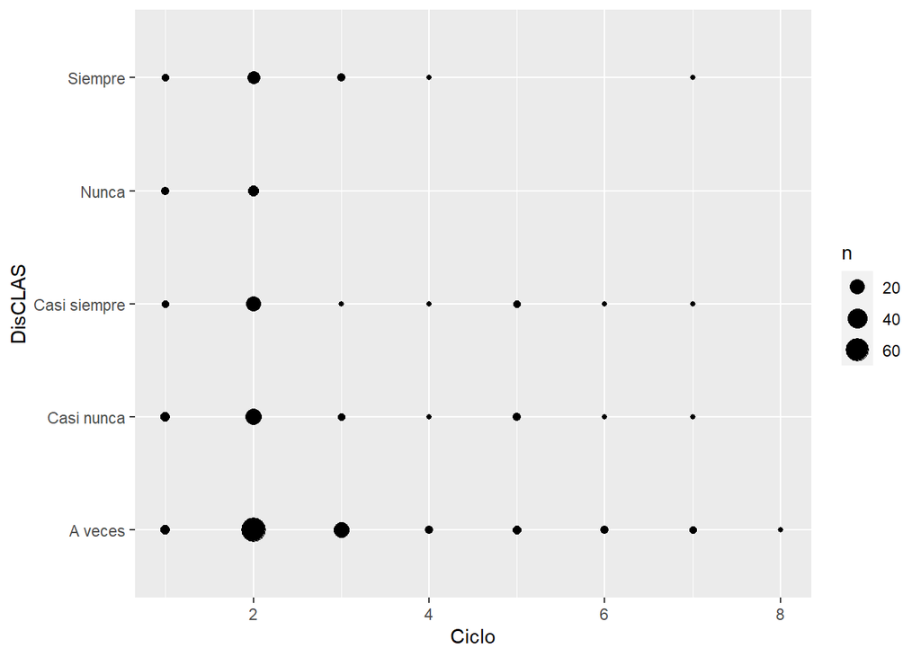

```r
ggplot(data = DBT) +
  geom_count(aes(Ciclo, DisCLAS))
```

## Género - Horas de estudio, fuera de clases

- Gracias a la gráfica se puede observar que los estudiantes del género femenino, emplean mas horas al estudio fuera de clases en comparacion al género masculino.

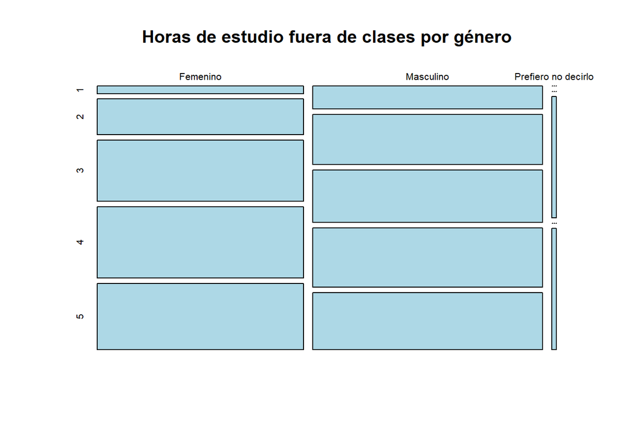

```r
plot(table(DBT$Genero, DBT$HsFC), main="Horas de estudio fuera de clases por género", col = "lightblue")
```

## Cantidad de aplicaciones - Horas de uso

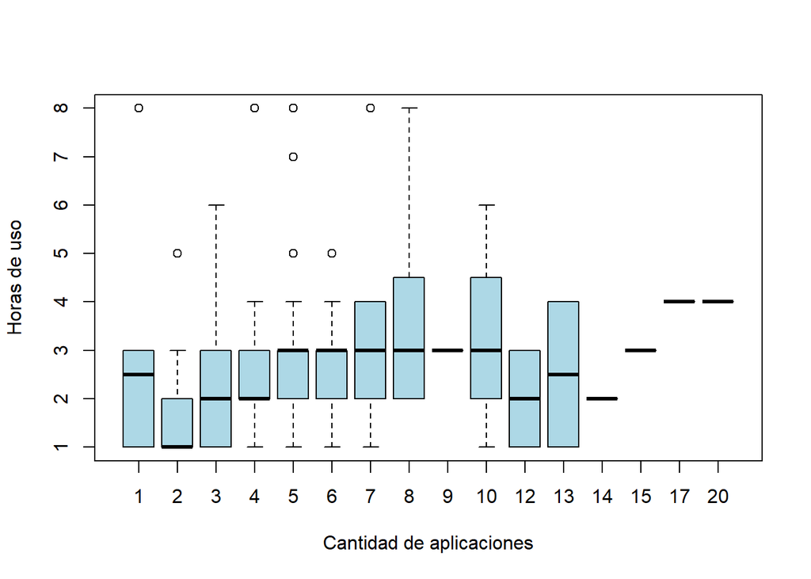

```r
boxplot(DBT$HorRs~DBT$CantiAPP, xlab = "Cantidad de aplicaciones", ylab = "Horas de uso", col=c("lightblue"))
```

## Edad - Horas de estudio

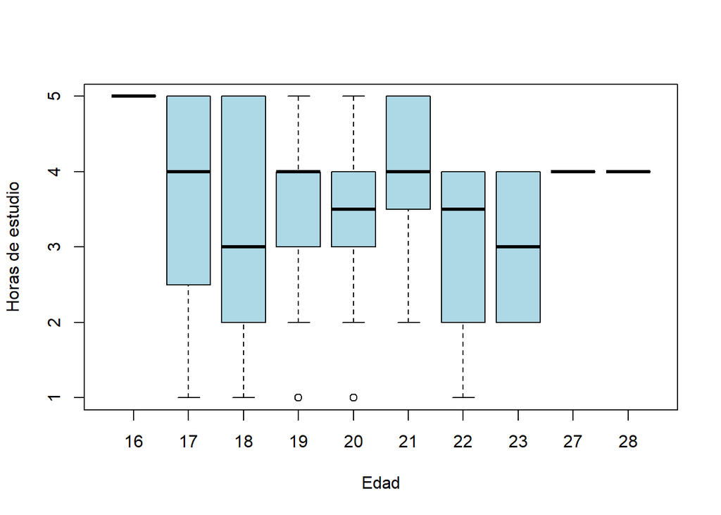

```r
boxplot(DBT$HsFC~DBT$Edad, xlab = "Edad", ylab = "Horas de estudio", col=c("lightblue"))
```

# **Análisis probabilístico**

Veremos el histograma de todas nuestras variables numericas.

```r
library(Hmisc)
```

[figure not shown]

[figure not shown]

```r
hist.data.frame(DBT)
```

### Modelo de distribución normal

Variable aleatoria : Edad

El primer paso para analizar una variable es hacer un histograma de la variable y ver su comportamiento.

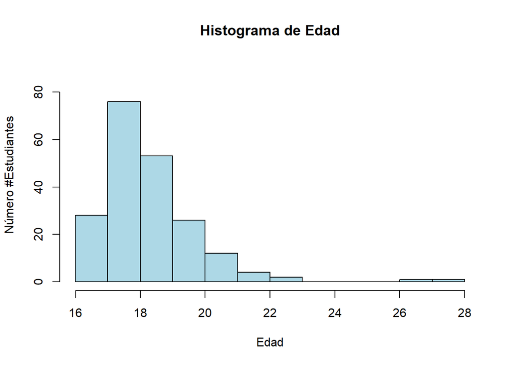

```r
hist(DBT$Edad, main = "Histograma de Edad", xlab = "Edad", ylab="Número #Estudiantes", col = "lightblue", ylim= c(0,90))
```

Procederemos a quitar los datos atípicos

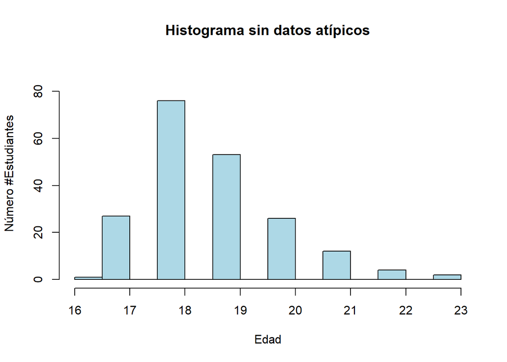

```r
edadNA <-  filter(DBT,as.integer(Edad)<24)
hist(edadNA$Edad,breaks = 10, main = "Histograma sin datos atípicos", xlab= "Edad", ylab="Número #Estudiantes",ylim= c(0,90), col = "lightblue")
```

Usaremos la funcion descdist para ver a que distribucion conocida se asemeja la variable edad

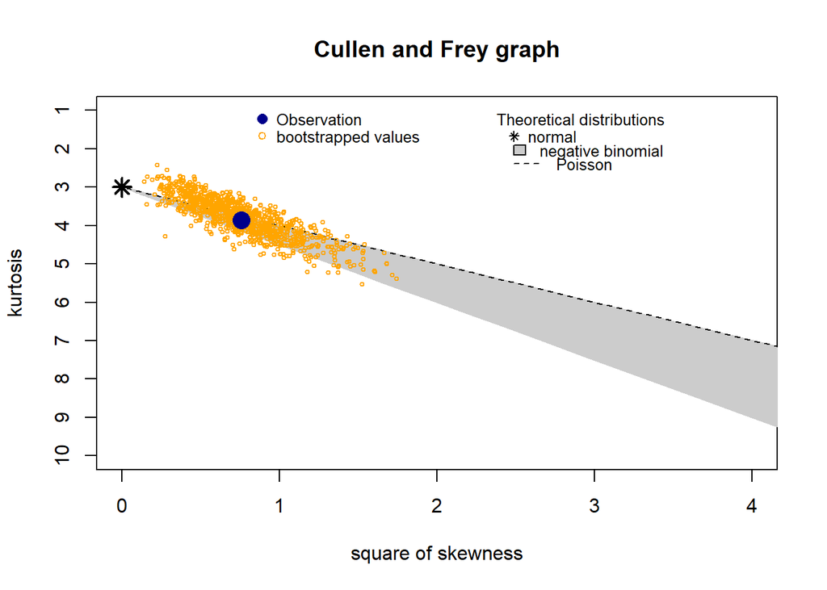

```
## summary statistics
## ------
## min:  16   max:  23
## median:  18
## mean:  18.68657
## estimated sd:  1.255495
## estimated skewness:  0.8717925
## estimated kurtosis:  3.860298
```

```r
library(fitdistrplus)
descdist(edadNA$Edad, discrete =TRUE, boot = 1000)
```

```r
fitdist(edadNA$Edad,"norm")
```

```
## Fitting of the distribution ' norm ' by maximum likelihood
## Parameters:
##       estimate Std. Error
## mean 18.686567 0.08833525
## sd    1.252368 0.06246228
```

Los parámetros de la distribución edad usando el estimador de maxima verosimilitud son los siguientes $Edad = Norm(18.68,1.25)$

Nosotros sabemos que nuestra distribución es discreta, sin embargo podemos asumir que la edad de los participantes puede ser continua ya que los participantes pueden tener una cantidad de años y una proporcion que representa la cantidad de dias que les falta para el próximo cumpleaños.

Ahora veremos si nuestra distribución teorica se parece a la empírica.

[figure not shown]

```r
hist(edadNA$Edad, freq = FALSE, col = "lightblue", xlab = "Edad", ylab= "Densidad", main = "Histograma de edad")
curve(dnorm(x,17.68,1.25),xlim=c(16,24),col="blue",lwd=2,
      xlab="x",ylab="f(x)",main="Histograma de densidad de la edad",add = TRUE)
```

Ahora nos haremos preguntas para saber sobre la edad de nuestros participantes.

1. ¿Cual es la probabilidad de de la variable aleatoria X ~ Edad del participante sea menor o igual 17?

Esta pregunta corresponde a la probabilidad de que un menor de edad use las redes sociales.

```r
pnorm(17,18.68,1.25)
```

```
## [1] 0.08947419
```

2. La probabilidad de que un menor de edad use redes sociales entre nuestros encuestados es de $0.09$

¿Cual es la probabilidad de que un estudiante al azar que use redes sociales tenga entre 20 y 21 años?

```r
pnorm(21,18.68,1.25)-pnorm(20,18.68,1.25)
```

```
## [1] 0.1137573
```

### Modelo binomial negativa

Variable aleatoria : Cantidad de aplicaciones - CantiApp

La variable CantiApp hace referencia a la cantidad de aplicaciones de redes sociales que el encuestado tiene instalada en el celular. Nosotros creemos que esta variable es de relevancia para nuestro estudio debido a que veremos si la cantidad de aplicaciones instaladas tiene una relación con el tiempo que este estudiante pasa en redes sociales.

Primero veremos en un histograma como se comporta la variable.

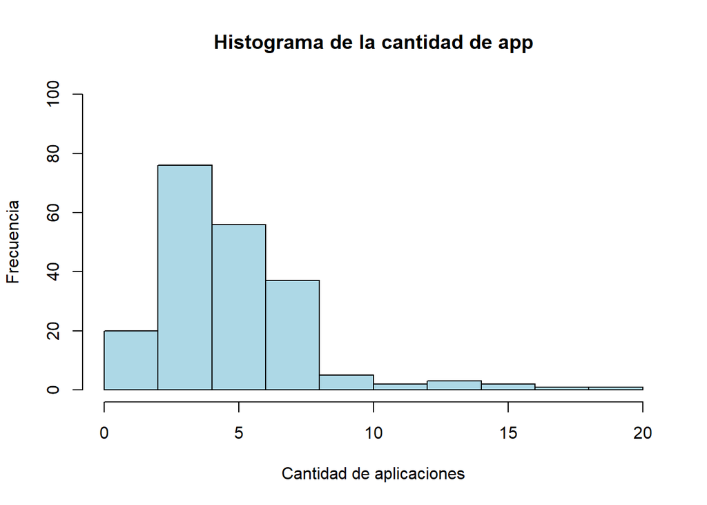

```r
hist(DBT$CantiAPP, col = "lightblue", xlab = "Cantidad de aplicaciones", ylab = "Frecuencia", main = "Histograma de la cantidad de app", ylim =c(0,100))
```

Como vemos, a primera vista no podemos identificar una distribución clara. Ahora nos ayudaremos de la funcion descdist para ver a que distribución se asemeja la variable cantidad de apps.

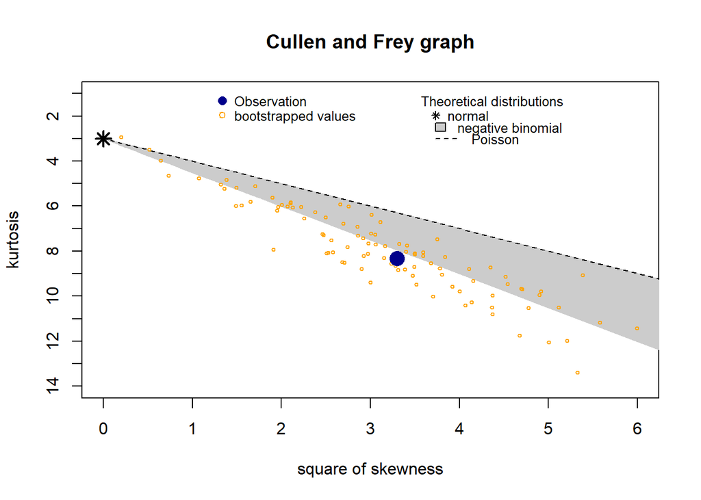

```
## summary statistics
## ------
## min:  1   max:  20
## median:  5
## mean:  5.206897
## estimated sd:  2.867806
## estimated skewness:  1.816061
## estimated kurtosis:  8.323686
```

```r
descdist(DBT$CantiAPP,discrete = TRUE,boot=100)
```

Como podemos observar en el grafico Cullen and Frey, la distribucion de la variable Cantidad de Apps se asemeja a una distribucion binomial negativa. Ahora estimaremos los parametros usando la funcion fitdistr

```r
fitdist(DBT$CantiAPP, "nbinom")
```

```
## Fitting of the distribution ' nbinom ' by maximum likelihood
## Parameters:
##       estimate Std. Error
## size 12.290545  3.8217044
## mu    5.206693  0.1910826
```

$Aplicaciones = nbinom(12.29,5.2)$

Ahora que estimamos los parámetros de la variable vamos a comprar la distribución teórica con la empírica.

```r
x1=seq(0,20,by=1)
x2<-dnbinom(x1,size =12.9,mu = 5.2)
```

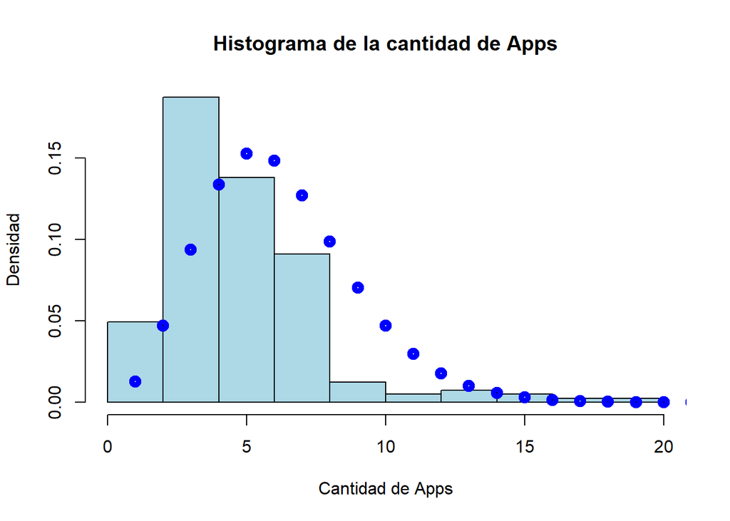

```r
hist(DBT$CantiAPP, freq = FALSE, main = "Histograma de la cantidad de Apps",xlab = "Cantidad de Apps", ylab = "Densidad", col = "lightblue")
points(x2,xlim=c(0,20),col="blue",lwd=5)
```

1. ¿Cual es la probabilidad de que una persona tenga 6 aplicaciones instaladas?

```r
dnbinom(6,size = 12.9, mu = 5.2)
```

```
## [1] 0.1270859
```